# Clustering

```
(<Figure size 1500x1000 with 1 Axes>,
 <Axes: title={'center': 'Cumulative explained variance\n 3 Principal Components explain [90.37%] of the variance.'}, xlabel='Principal Component', ylabel='Percentage explained variance'>)
```

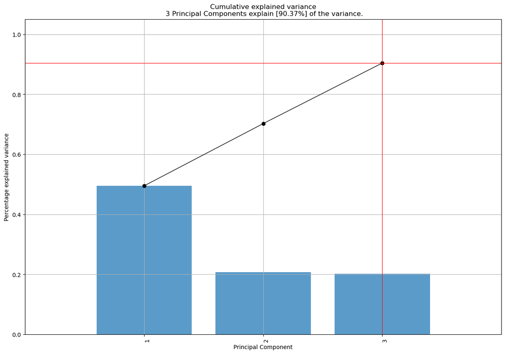

[output not shown]

```python
pcaModel.plot()
```

```python
# Acceso a las cargas
pcaModel.results['loadings']
```

|  | revenues | foundation year | ESG score | environmental score (ESG) | social score (ESG) |
| --- | --- | --- | --- | --- | --- |
| PC1 | -0.042084 | 0.540071 | 0.374618 | 0.590384 | -0.466541 |
| PC2 | 0.015715 | 0.078310 | 0.766961 | -0.055983 | 0.634237 |
| PC3 | 0.990510 | 0.120037 | -0.010340 | -0.057905 | -0.031971 |

[output not shown]

Variables dominantes: Puntuación ESG (0,766961), puntuación social (ESG) (0,634237). Contribución moderada: año de fundación (0,078310). Contribución negativa: puntuación medioambiental (ESG) (-0,055983). Interpretación: PC2 capta el eje ESG-social, con una alta puntuación ESG y una puntuación social que indican los puntos fuertes sociales de las empresas más nuevas (por ejemplo, 32 empleados con alta ESG social). La puntuación medioambiental negativa refleja la compensación (correlación -0,707), y los bajos ingresos (0,015715) refuerzan su irrelevancia.

- PC3 (Componetes terciario, ~20.27%):

Variable dominante: ingresos (0,990510). Contribuciones menores: año de fundación (0,120037), puntuación ESG (-0,010340), puntuación medioambiental (ESG) (-0,057905), puntuación social (ESG) (-0,031971). Interpretación: PC3 está impulsado casi en su totalidad por los ingresos, probablemente debido a sus valores uniformes anómalos (por ejemplo, 60M+). Este componente capta el ruido en lugar de una estructura significativa, lo que explica la baja puntuación del KMO (0,2486 para los ingresos) y apoya su exclusión.

```
[07-09-2025 00:03:25] [pca.pca] [INFO] Plot PC1 vs PC2 with loadings.
[07-09-2025 00:03:25] [scatterd.scatterd] [INFO] Create scatterplot
```

```
(<Figure size 2500x1500 with 1 Axes>,
 <Axes: title={'center': '3 Principal Components explain [90.37%] of the variance'}, xlabel='PC1 (49.4% expl.var)', ylabel='PC2 (20.7% expl.var)'>)
```

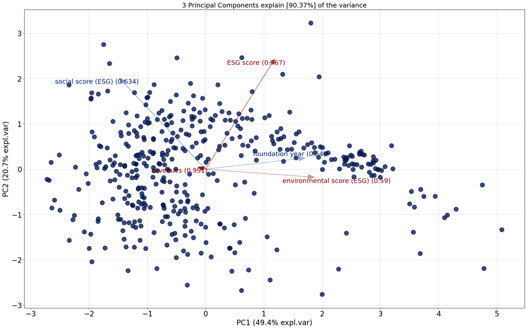

```python
pcaModel.biplot(legend=False)
```